# Risk Factor Analysis

## Outcome Variable

**Outcome Variable:** wast_rec90d

## Predictor Variables

**Intervention Variable:** birthlen

**Adjustment Set:**

- arm
- sex
- W_mage
- meducyrs
- feducyrs
- vagbrth
- single
- brthmon
- W_parity
- delta_W_mage
- delta_meducyrs
- delta_feducyrs
- delta_vagbrth
- delta_single
- delta_brthmon
- delta_W_parity

## Stratifying Variables

The analysis was stratified on these variable(s):

- agecat
- studyid
- country

## Data Summary

| agecat | studyid | country | birthlen | wast_rec90d | n_cell | n |
| --- | --- | --- | --- | --- | --- | --- |
| 0-24 months | CMC-V-BCS-2002 | INDIA | >=50 cm | 0 | 3 | 88 |
| 0-24 months | CMC-V-BCS-2002 | INDIA | >=50 cm | 1 | 3 | 88 |
| 0-24 months | CMC-V-BCS-2002 | INDIA | <48 cm | 0 | 19 | 88 |
| 0-24 months | CMC-V-BCS-2002 | INDIA | <48 cm | 1 | 27 | 88 |
| 0-24 months | CMC-V-BCS-2002 | INDIA | [48-50) cm | 0 | 9 | 88 |
| 0-24 months | CMC-V-BCS-2002 | INDIA | [48-50) cm | 1 | 27 | 88 |
| 0-24 months | CMIN | BANGLADESH | >=50 cm | 0 | 1 | 12 |
| 0-24 months | CMIN | BANGLADESH | >=50 cm | 1 | 0 | 12 |
| 0-24 months | CMIN | BANGLADESH | <48 cm | 0 | 4 | 12 |
| 0-24 months | CMIN | BANGLADESH | <48 cm | 1 | 3 | 12 |
| 0-24 months | CMIN | BANGLADESH | [48-50) cm | 0 | 0 | 12 |
| 0-24 months | CMIN | BANGLADESH | [48-50) cm | 1 | 4 | 12 |
| 0-24 months | COHORTS | GUATEMALA | >=50 cm | 0 | 59 | 295 |
| 0-24 months | COHORTS | GUATEMALA | >=50 cm | 1 | 118 | 295 |
| 0-24 months | COHORTS | GUATEMALA | <48 cm | 0 | 33 | 295 |
| 0-24 months | COHORTS | GUATEMALA | <48 cm | 1 | 11 | 295 |
| 0-24 months | COHORTS | GUATEMALA | [48-50) cm | 0 | 35 | 295 |
| 0-24 months | COHORTS | GUATEMALA | [48-50) cm | 1 | 39 | 295 |
| 0-24 months | COHORTS | INDIA | >=50 cm | 0 | 338 | 2497 |
| 0-24 months | COHORTS | INDIA | >=50 cm | 1 | 186 | 2497 |
| 0-24 months | COHORTS | INDIA | <48 cm | 0 | 862 | 2497 |
| 0-24 months | COHORTS | INDIA | <48 cm | 1 | 211 | 2497 |
| 0-24 months | COHORTS | INDIA | [48-50) cm | 0 | 653 | 2497 |
| 0-24 months | COHORTS | INDIA | [48-50) cm | 1 | 247 | 2497 |
| 0-24 months | COHORTS | PHILIPPINES | >=50 cm | 0 | 190 | 1686 |
| 0-24 months | COHORTS | PHILIPPINES | >=50 cm | 1 | 423 | 1686 |
| 0-24 months | COHORTS | PHILIPPINES | <48 cm | 0 | 218 | 1686 |
| 0-24 months | COHORTS | PHILIPPINES | <48 cm | 1 | 259 | 1686 |
| 0-24 months | COHORTS | PHILIPPINES | [48-50) cm | 0 | 255 | 1686 |
| 0-24 months | COHORTS | PHILIPPINES | [48-50) cm | 1 | 341 | 1686 |

[output cut: 420 more lines]

The following strata were considered:

- agecat: 0-24 months, studyid: CMC-V-BCS-2002, country: INDIA
- agecat: 0-24 months, studyid: CMIN, country: BANGLADESH
- agecat: 0-24 months, studyid: COHORTS, country: GUATEMALA
- agecat: 0-24 months, studyid: COHORTS, country: INDIA
- agecat: 0-24 months, studyid: COHORTS, country: PHILIPPINES
- agecat: 0-24 months, studyid: EE, country: PAKISTAN
- agecat: 0-24 months, studyid: GMS-Nepal, country: NEPAL
- agecat: 0-24 months, studyid: IRC, country: INDIA
- agecat: 0-24 months, studyid: JiVitA-3, country: BANGLADESH
- agecat: 0-24 months, studyid: JiVitA-4, country: BANGLADESH
- agecat: 0-24 months, studyid: Keneba, country: GAMBIA
- agecat: 0-24 months, studyid: MAL-ED, country: BANGLADESH
- agecat: 0-24 months, studyid: MAL-ED, country: BRAZIL
- agecat: 0-24 months, studyid: MAL-ED, country: INDIA
- agecat: 0-24 months, studyid: MAL-ED, country: NEPAL
- agecat: 0-24 months, studyid: MAL-ED, country: PERU
- agecat: 0-24 months, studyid: MAL-ED, country: SOUTH AFRICA
- agecat: 0-24 months, studyid: MAL-ED, country: TANZANIA, UNITED REPUBLIC OF
- agecat: 0-24 months, studyid: NIH-Birth, country: BANGLADESH
- agecat: 0-24 months, studyid: NIH-Crypto, country: BANGLADESH
- agecat: 0-24 months, studyid: PROBIT, country: BELARUS
- agecat: 0-24 months, studyid: PROVIDE, country: BANGLADESH
- agecat: 0-24 months, studyid: ResPak, country: PAKISTAN
- agecat: 0-24 months, studyid: SAS-CompFeed, country: INDIA
- agecat: 0-24 months, studyid: ZVITAMBO, country: ZIMBABWE
- agecat: 0-6 months, studyid: CMC-V-BCS-2002, country: INDIA
- agecat: 0-6 months, studyid: CMIN, country: BANGLADESH
- agecat: 0-6 months, studyid: COHORTS, country: GUATEMALA
- agecat: 0-6 months, studyid: COHORTS, country: INDIA
- agecat: 0-6 months, studyid: COHORTS, country: PHILIPPINES
- agecat: 0-6 months, studyid: EE, country: PAKISTAN
- agecat: 0-6 months, studyid: GMS-Nepal, country: NEPAL
- agecat: 0-6 months, studyid: IRC, country: INDIA
- agecat: 0-6 months, studyid: JiVitA-3, country: BANGLADESH
- agecat: 0-6 months, studyid: JiVitA-4, country: BANGLADESH
- agecat: 0-6 months, studyid: Keneba, country: GAMBIA
- agecat: 0-6 months, studyid: MAL-ED, country: BANGLADESH
- agecat: 0-6 months, studyid: MAL-ED, country: BRAZIL
- agecat: 0-6 months, studyid: MAL-ED, country: INDIA
- agecat: 0-6 months, studyid: MAL-ED, country: NEPAL
- agecat: 0-6 months, studyid: MAL-ED, country: PERU
- agecat: 0-6 months, studyid: MAL-ED, country: SOUTH AFRICA
- agecat: 0-6 months, studyid: MAL-ED, country: TANZANIA, UNITED REPUBLIC OF
- agecat: 0-6 months, studyid: NIH-Birth, country: BANGLADESH
- agecat: 0-6 months, studyid: NIH-Crypto, country: BANGLADESH
- agecat: 0-6 months, studyid: PROBIT, country: BELARUS
- agecat: 0-6 months, studyid: PROVIDE, country: BANGLADESH
- agecat: 0-6 months, studyid: ResPak, country: PAKISTAN
- agecat: 0-6 months, studyid: SAS-CompFeed, country: INDIA
- agecat: 0-6 months, studyid: ZVITAMBO, country: ZIMBABWE
- agecat: 6-24 months, studyid: CMC-V-BCS-2002, country: INDIA
- agecat: 6-24 months, studyid: CMIN, country: BANGLADESH
- agecat: 6-24 months, studyid: COHORTS, country: GUATEMALA
- agecat: 6-24 months, studyid: COHORTS, country: INDIA
- agecat: 6-24 months, studyid: COHORTS, country: PHILIPPINES
- agecat: 6-24 months, studyid: EE, country: PAKISTAN
- agecat: 6-24 months, studyid: GMS-Nepal, country: NEPAL
- agecat: 6-24 months, studyid: IRC, country: INDIA
- agecat: 6-24 months, studyid: JiVitA-3, country: BANGLADESH
- agecat: 6-24 months, studyid: JiVitA-4, country: BANGLADESH
- agecat: 6-24 months, studyid: Keneba, country: GAMBIA
- agecat: 6-24 months, studyid: MAL-ED, country: BANGLADESH
- agecat: 6-24 months, studyid: MAL-ED, country: BRAZIL
- agecat: 6-24 months, studyid: MAL-ED, country: INDIA
- agecat: 6-24 months, studyid: MAL-ED, country: NEPAL
- agecat: 6-24 months, studyid: MAL-ED, country: PERU
- agecat: 6-24 months, studyid: MAL-ED, country: SOUTH AFRICA
- agecat: 6-24 months, studyid: MAL-ED, country: TANZANIA, UNITED REPUBLIC OF
- agecat: 6-24 months, studyid: NIH-Birth, country: BANGLADESH
- agecat: 6-24 months, studyid: NIH-Crypto, country: BANGLADESH
- agecat: 6-24 months, studyid: PROBIT, country: BELARUS
- agecat: 6-24 months, studyid: PROVIDE, country: BANGLADESH
- agecat: 6-24 months, studyid: ResPak, country: PAKISTAN
- agecat: 6-24 months, studyid: SAS-CompFeed, country: INDIA
- agecat: 6-24 months, studyid: ZVITAMBO, country: ZIMBABWE

### Dropped Strata

Some strata were dropped due to rare outcomes:

- agecat: 0-24 months, studyid: CMC-V-BCS-2002, country: INDIA
- agecat: 0-24 months, studyid: CMIN, country: BANGLADESH
- agecat: 0-24 months, studyid: MAL-ED, country: BRAZIL
- agecat: 0-24 months, studyid: MAL-ED, country: INDIA
- agecat: 0-24 months, studyid: MAL-ED, country: NEPAL
- agecat: 0-24 months, studyid: MAL-ED, country: PERU
- agecat: 0-24 months, studyid: MAL-ED, country: SOUTH AFRICA
- agecat: 0-24 months, studyid: MAL-ED, country: TANZANIA, UNITED REPUBLIC OF
- agecat: 0-24 months, studyid: ResPak, country: PAKISTAN
- agecat: 0-6 months, studyid: CMC-V-BCS-2002, country: INDIA
- agecat: 0-6 months, studyid: CMIN, country: BANGLADESH
- agecat: 0-6 months, studyid: EE, country: PAKISTAN
- agecat: 0-6 months, studyid: MAL-ED, country: BANGLADESH
- agecat: 0-6 months, studyid: MAL-ED, country: BRAZIL
- agecat: 0-6 months, studyid: MAL-ED, country: INDIA
- agecat: 0-6 months, studyid: MAL-ED, country: NEPAL
- agecat: 0-6 months, studyid: MAL-ED, country: PERU
- agecat: 0-6 months, studyid: MAL-ED, country: SOUTH AFRICA
- agecat: 0-6 months, studyid: MAL-ED, country: TANZANIA, UNITED REPUBLIC OF
- agecat: 0-6 months, studyid: NIH-Crypto, country: BANGLADESH
- agecat: 0-6 months, studyid: PROBIT, country: BELARUS
- agecat: 0-6 months, studyid: ResPak, country: PAKISTAN
- agecat: 6-24 months, studyid: CMC-V-BCS-2002, country: INDIA
- agecat: 6-24 months, studyid: CMIN, country: BANGLADESH
- agecat: 6-24 months, studyid: COHORTS, country: GUATEMALA
- agecat: 6-24 months, studyid: COHORTS, country: INDIA
- agecat: 6-24 months, studyid: EE, country: PAKISTAN
- agecat: 6-24 months, studyid: JiVitA-3, country: BANGLADESH
- agecat: 6-24 months, studyid: MAL-ED, country: BANGLADESH
- agecat: 6-24 months, studyid: MAL-ED, country: BRAZIL
- agecat: 6-24 months, studyid: MAL-ED, country: INDIA
- agecat: 6-24 months, studyid: MAL-ED, country: NEPAL
- agecat: 6-24 months, studyid: MAL-ED, country: PERU
- agecat: 6-24 months, studyid: MAL-ED, country: SOUTH AFRICA
- agecat: 6-24 months, studyid: MAL-ED, country: TANZANIA, UNITED REPUBLIC OF
- agecat: 6-24 months, studyid: NIH-Crypto, country: BANGLADESH
- agecat: 6-24 months, studyid: PROBIT, country: BELARUS
- agecat: 6-24 months, studyid: PROVIDE, country: BANGLADESH
- agecat: 6-24 months, studyid: ResPak, country: PAKISTAN

## Methods Detail

We’re interested in the causal parameters $E[Y_a]$ for all values of $a \in \mathcal{A}$. These parameters represent the mean outcome if, possibly contrary to fact, we intervened to set all units to have $A=a$. Under the randomization and positivity assumptions, these are identified by the statistical parameters $\psi_a=E_W[E_{Y|A,W}(Y|A=a,W)]$. In addition, we’re interested in the mean of $Y$, $E[Y]$ under no intervention (the observed mean). We will estimate these parameters by using SuperLearner to fit the relevant likelihood factors – $E_{Y|A,W}(Y|A=a,W)$ and $p(A=a|W)$, and then updating our likelihood fit using a joint TMLE.

For unadjusted analyses ($W=\{\}$), initial likelihoods were estimated using Lrnr_glm to estimate the simple $E(Y|A)$ and Lrnr_mean to estimate $p(A)$. For adjusted analyses, a small library containing Lrnr_glmnet, Lrnr_xgboost, and Lrnr_mean was used.

Having estimated these parameters, we will then use the delta method to estimate relative risks and attributable risks relative to a prespecified baseline level of $A$.

# Results Detail

## Results Plots

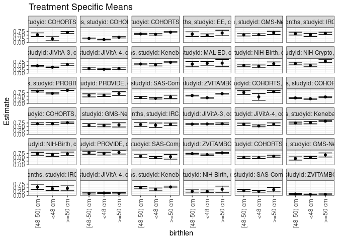

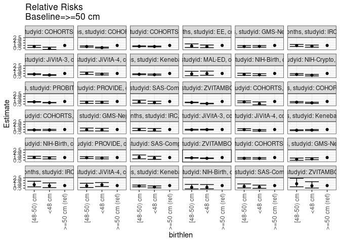

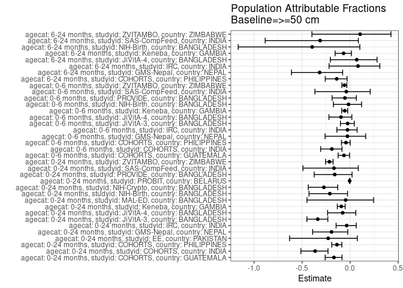

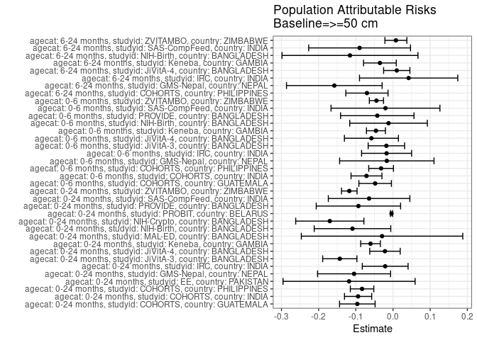

## Results Table

### Parameter: TSM

| agecat | studyid | country | intervention_level | baseline_level | estimate | ci_lower | ci_upper |
| --- | --- | --- | --- | --- | --- | --- | --- |
| 0-24 months | COHORTS | GUATEMALA | >=50 cm | NA | 0.6654114 | 0.5955353 | 0.7352874 |
| 0-24 months | COHORTS | GUATEMALA | <48 cm | NA | 0.2566061 | 0.1221552 | 0.3910569 |
| 0-24 months | COHORTS | GUATEMALA | [48-50) cm | NA | 0.5229871 | 0.4027103 | 0.6432639 |
| 0-24 months | COHORTS | INDIA | >=50 cm | NA | 0.3518361 | 0.3095641 | 0.3941081 |
| 0-24 months | COHORTS | INDIA | <48 cm | NA | 0.2003823 | 0.1766787 | 0.2240859 |
| 0-24 months | COHORTS | INDIA | [48-50) cm | NA | 0.2758661 | 0.2464477 | 0.3052846 |
| 0-24 months | COHORTS | PHILIPPINES | >=50 cm | NA | 0.6900527 | 0.6514614 | 0.7286440 |
| 0-24 months | COHORTS | PHILIPPINES | <48 cm | NA | 0.5472218 | 0.5019985 | 0.5924450 |
| 0-24 months | COHORTS | PHILIPPINES | [48-50) cm | NA | 0.5733732 | 0.5309092 | 0.6158373 |
| 0-24 months | EE | PAKISTAN | >=50 cm | NA | 0.6363636 | 0.4530706 | 0.8196567 |
| 0-24 months | EE | PAKISTAN | <48 cm | NA | 0.4904459 | 0.4037290 | 0.5771627 |
| 0-24 months | EE | PAKISTAN | [48-50) cm | NA | 0.5609756 | 0.4092507 | 0.7127005 |
| 0-24 months | GMS-Nepal | NEPAL | >=50 cm | NA | 0.6460906 | 0.5399658 | 0.7522155 |
| 0-24 months | GMS-Nepal | NEPAL | <48 cm | NA | 0.5227916 | 0.4644760 | 0.5811072 |
| 0-24 months | GMS-Nepal | NEPAL | [48-50) cm | NA | 0.5139296 | 0.4390308 | 0.5888283 |
| 0-24 months | IRC | INDIA | >=50 cm | NA | 0.6102162 | 0.5305774 | 0.6898549 |
| 0-24 months | IRC | INDIA | <48 cm | NA | 0.5130138 | 0.4108421 | 0.6151856 |
| 0-24 months | IRC | INDIA | [48-50) cm | NA | 0.5990826 | 0.5046116 | 0.6935536 |
| 0-24 months | JiVitA-3 | BANGLADESH | >=50 cm | NA | 0.5682713 | 0.5207400 | 0.6158027 |
| 0-24 months | JiVitA-3 | BANGLADESH | <48 cm | NA | 0.3949201 | 0.3805225 | 0.4093177 |
| 0-24 months | JiVitA-3 | BANGLADESH | [48-50) cm | NA | 0.4852126 | 0.4587675 | 0.5116578 |
| 0-24 months | JiVitA-4 | BANGLADESH | >=50 cm | NA | 0.3013187 | 0.2534698 | 0.3491675 |
| 0-24 months | JiVitA-4 | BANGLADESH | <48 cm | NA | 0.2605227 | 0.2324572 | 0.2885882 |
| 0-24 months | JiVitA-4 | BANGLADESH | [48-50) cm | NA | 0.3050249 | 0.2576683 | 0.3523814 |
| 0-24 months | Keneba | GAMBIA | >=50 cm | NA | 0.7209228 | 0.6854926 | 0.7563530 |
| 0-24 months | Keneba | GAMBIA | <48 cm | NA | 0.5501518 | 0.4743902 | 0.6259134 |
| 0-24 months | Keneba | GAMBIA | [48-50) cm | NA | 0.6063434 | 0.5524010 | 0.6602857 |
| 0-24 months | MAL-ED | BANGLADESH | >=50 cm | NA | 0.6666667 | 0.4286826 | 0.9046507 |
| 0-24 months | MAL-ED | BANGLADESH | <48 cm | NA | 0.6500000 | 0.5293253 | 0.7706747 |
| 0-24 months | MAL-ED | BANGLADESH | [48-50) cm | NA | 0.6000000 | 0.4226014 | 0.7773986 |

[output cut: 78 more lines]

### Parameter: E(Y)

| agecat | studyid | country | intervention_level | baseline_level | estimate | ci_lower | ci_upper |
| --- | --- | --- | --- | --- | --- | --- | --- |
| 0-24 months | COHORTS | GUATEMALA | NA | NA | 0.5694915 | 0.5120418 | 0.6269413 |
| 0-24 months | COHORTS | INDIA | NA | NA | 0.2579095 | 0.2406335 | 0.2751855 |
| 0-24 months | COHORTS | PHILIPPINES | NA | NA | 0.6067616 | 0.5822457 | 0.6312775 |
| 0-24 months | EE | PAKISTAN | NA | NA | 0.5181818 | 0.4466550 | 0.5897087 |
| 0-24 months | GMS-Nepal | NEPAL | NA | NA | 0.5413417 | 0.4990070 | 0.5836763 |
| 0-24 months | IRC | INDIA | NA | NA | 0.5891473 | 0.5364145 | 0.6418800 |
| 0-24 months | JiVitA-3 | BANGLADESH | NA | NA | 0.4251535 | 0.4129986 | 0.4373083 |
| 0-24 months | JiVitA-4 | BANGLADESH | NA | NA | 0.2796610 | 0.2580570 | 0.3012650 |
| 0-24 months | Keneba | GAMBIA | NA | NA | 0.6604082 | 0.6324757 | 0.6883406 |
| 0-24 months | MAL-ED | BANGLADESH | NA | NA | 0.6371681 | 0.5446961 | 0.7296402 |
| 0-24 months | NIH-Birth | BANGLADESH | NA | NA | 0.5171569 | 0.4657250 | 0.5685888 |
| 0-24 months | NIH-Crypto | BANGLADESH | NA | NA | 0.6225806 | 0.5684562 | 0.6767051 |
| 0-24 months | PROBIT | BELARUS | NA | NA | 0.8806715 | 0.8711794 | 0.8901636 |
| 0-24 months | PROVIDE | BANGLADESH | NA | NA | 0.5811688 | 0.5245443 | 0.6377934 |
| 0-24 months | SAS-CompFeed | INDIA | NA | NA | 0.3831891 | 0.3479331 | 0.4184451 |
| 0-24 months | ZVITAMBO | ZIMBABWE | NA | NA | 0.5452017 | 0.5287719 | 0.5616314 |
| 0-6 months | COHORTS | GUATEMALA | NA | NA | 0.7547170 | 0.6968087 | 0.8126253 |
| 0-6 months | COHORTS | INDIA | NA | NA | 0.3748545 | 0.3519572 | 0.3977518 |
| 0-6 months | COHORTS | PHILIPPINES | NA | NA | 0.7363515 | 0.7047428 | 0.7679603 |
| 0-6 months | GMS-Nepal | NEPAL | NA | NA | 0.6045627 | 0.5449300 | 0.6641955 |
| 0-6 months | IRC | INDIA | NA | NA | 0.6398305 | 0.5770134 | 0.7026476 |
| 0-6 months | JiVitA-3 | BANGLADESH | NA | NA | 0.6818985 | 0.6673935 | 0.6964035 |
| 0-6 months | JiVitA-4 | BANGLADESH | NA | NA | 0.6130952 | 0.5705324 | 0.6556580 |
| 0-6 months | Keneba | GAMBIA | NA | NA | 0.8259325 | 0.7956783 | 0.8561867 |
| 0-6 months | NIH-Birth | BANGLADESH | NA | NA | 0.7142857 | 0.6541352 | 0.7744362 |
| 0-6 months | PROVIDE | BANGLADESH | NA | NA | 0.7837838 | 0.7252863 | 0.8422812 |
| 0-6 months | SAS-CompFeed | INDIA | NA | NA | 0.5147059 | 0.4610948 | 0.5683169 |
| 0-6 months | ZVITAMBO | ZIMBABWE | NA | NA | 0.7472178 | 0.7302477 | 0.7641880 |
| 6-24 months | COHORTS | PHILIPPINES | NA | NA | 0.5026738 | 0.4688037 | 0.5365439 |
| 6-24 months | GMS-Nepal | NEPAL | NA | NA | 0.4973545 | 0.4426760 | 0.5520330 |
| 6-24 months | IRC | INDIA | NA | NA | 0.5099338 | 0.4248374 | 0.5950302 |
| 6-24 months | JiVitA-4 | BANGLADESH | NA | NA | 0.1469194 | 0.1276367 | 0.1662021 |
| 6-24 months | Keneba | GAMBIA | NA | NA | 0.5196375 | 0.4788178 | 0.5604571 |
| 6-24 months | NIH-Birth | BANGLADESH | NA | NA | 0.2931937 | 0.2273732 | 0.3590142 |
| 6-24 months | SAS-CompFeed | INDIA | NA | NA | 0.2878465 | 0.2457514 | 0.3299415 |
| 6-24 months | ZVITAMBO | ZIMBABWE | NA | NA | 0.0741427 | 0.0585455 | 0.0897399 |

### Parameter: RR

| agecat | studyid | country | intervention_level | baseline_level | estimate | ci_lower | ci_upper |
| --- | --- | --- | --- | --- | --- | --- | --- |
| 0-24 months | COHORTS | GUATEMALA | >=50 cm | >=50 cm | 1.0000000 | 1.0000000 | 1.0000000 |
| 0-24 months | COHORTS | GUATEMALA | <48 cm | >=50 cm | 0.3856352 | 0.2258836 | 0.6583679 |
| 0-24 months | COHORTS | GUATEMALA | [48-50) cm | >=50 cm | 0.7859606 | 0.6101058 | 1.0125031 |
| 0-24 months | COHORTS | INDIA | >=50 cm | >=50 cm | 1.0000000 | 1.0000000 | 1.0000000 |
| 0-24 months | COHORTS | INDIA | <48 cm | >=50 cm | 0.5695331 | 0.4812732 | 0.6739787 |
| 0-24 months | COHORTS | INDIA | [48-50) cm | >=50 cm | 0.7840757 | 0.6678589 | 0.9205158 |
| 0-24 months | COHORTS | PHILIPPINES | >=50 cm | >=50 cm | 1.0000000 | 1.0000000 | 1.0000000 |
| 0-24 months | COHORTS | PHILIPPINES | <48 cm | >=50 cm | 0.7930145 | 0.7177742 | 0.8761418 |
| 0-24 months | COHORTS | PHILIPPINES | [48-50) cm | >=50 cm | 0.8309123 | 0.7573850 | 0.9115776 |
| 0-24 months | EE | PAKISTAN | >=50 cm | >=50 cm | 1.0000000 | 1.0000000 | 1.0000000 |
| 0-24 months | EE | PAKISTAN | <48 cm | >=50 cm | 0.7707006 | 0.5499261 | 1.0801077 |
| 0-24 months | EE | PAKISTAN | [48-50) cm | >=50 cm | 0.8815331 | 0.5935933 | 1.3091465 |
| 0-24 months | GMS-Nepal | NEPAL | >=50 cm | >=50 cm | 1.0000000 | 1.0000000 | 1.0000000 |
| 0-24 months | GMS-Nepal | NEPAL | <48 cm | >=50 cm | 0.8091614 | 0.6636125 | 0.9866333 |
| 0-24 months | GMS-Nepal | NEPAL | [48-50) cm | >=50 cm | 0.7954450 | 0.6386622 | 0.9907159 |
| 0-24 months | IRC | INDIA | >=50 cm | >=50 cm | 1.0000000 | 1.0000000 | 1.0000000 |
| 0-24 months | IRC | INDIA | <48 cm | >=50 cm | 0.8407084 | 0.6626992 | 1.0665330 |
| 0-24 months | IRC | INDIA | [48-50) cm | >=50 cm | 0.9817547 | 0.8001030 | 1.2046477 |
| 0-24 months | JiVitA-3 | BANGLADESH | >=50 cm | >=50 cm | 1.0000000 | 1.0000000 | 1.0000000 |
| 0-24 months | JiVitA-3 | BANGLADESH | <48 cm | >=50 cm | 0.6949499 | 0.6343620 | 0.7613245 |
| 0-24 months | JiVitA-3 | BANGLADESH | [48-50) cm | >=50 cm | 0.8538397 | 0.7727464 | 0.9434431 |
| 0-24 months | JiVitA-4 | BANGLADESH | >=50 cm | >=50 cm | 1.0000000 | 1.0000000 | 1.0000000 |
| 0-24 months | JiVitA-4 | BANGLADESH | <48 cm | >=50 cm | 0.8646086 | 0.7136633 | 1.0474800 |
| 0-24 months | JiVitA-4 | BANGLADESH | [48-50) cm | >=50 cm | 1.0122999 | 0.8106621 | 1.2640914 |
| 0-24 months | Keneba | GAMBIA | >=50 cm | >=50 cm | 1.0000000 | 1.0000000 | 1.0000000 |
| 0-24 months | Keneba | GAMBIA | <48 cm | >=50 cm | 0.7631216 | 0.6594560 | 0.8830834 |
| 0-24 months | Keneba | GAMBIA | [48-50) cm | >=50 cm | 0.8410656 | 0.7596870 | 0.9311614 |
| 0-24 months | MAL-ED | BANGLADESH | >=50 cm | >=50 cm | 1.0000000 | 1.0000000 | 1.0000000 |
| 0-24 months | MAL-ED | BANGLADESH | <48 cm | >=50 cm | 0.9750000 | 0.6519879 | 1.4580409 |
| 0-24 months | MAL-ED | BANGLADESH | [48-50) cm | >=50 cm | 0.9000000 | 0.5660784 | 1.4308972 |

[output cut: 78 more lines]

### Parameter: PAR

| agecat | studyid | country | intervention_level | baseline_level | estimate | ci_lower | ci_upper |
| --- | --- | --- | --- | --- | --- | --- | --- |
| 0-24 months | COHORTS | GUATEMALA | >=50 cm | NA | -0.0959198 | -0.1437631 | -0.0480765 |
| 0-24 months | COHORTS | INDIA | >=50 cm | NA | -0.0939266 | -0.1304920 | -0.0573612 |
| 0-24 months | COHORTS | PHILIPPINES | >=50 cm | NA | -0.0832911 | -0.1148153 | -0.0517670 |
| 0-24 months | EE | PAKISTAN | >=50 cm | NA | -0.1181818 | -0.2958163 | 0.0594526 |
| 0-24 months | GMS-Nepal | NEPAL | >=50 cm | NA | -0.1047490 | -0.2029220 | -0.0065760 |
| 0-24 months | IRC | INDIA | >=50 cm | NA | -0.0210689 | -0.0826579 | 0.0405201 |
| 0-24 months | JiVitA-3 | BANGLADESH | >=50 cm | NA | -0.1431179 | -0.1891775 | -0.0970582 |
| 0-24 months | JiVitA-4 | BANGLADESH | >=50 cm | NA | -0.0216577 | -0.0627021 | 0.0193868 |
| 0-24 months | Keneba | GAMBIA | >=50 cm | NA | -0.0605146 | -0.0869671 | -0.0340622 |
| 0-24 months | MAL-ED | BANGLADESH | >=50 cm | NA | -0.0294985 | -0.2465936 | 0.1875965 |
| 0-24 months | NIH-Birth | BANGLADESH | >=50 cm | NA | -0.1090398 | -0.2119846 | -0.0060951 |
| 0-24 months | NIH-Crypto | BANGLADESH | >=50 cm | NA | -0.1700157 | -0.2617151 | -0.0783163 |
| 0-24 months | PROBIT | BELARUS | >=50 cm | NA | -0.0040270 | -0.0068724 | -0.0011816 |
| 0-24 months | PROVIDE | BANGLADESH | >=50 cm | NA | -0.0930742 | -0.2065320 | 0.0203836 |
| 0-24 months | SAS-CompFeed | INDIA | >=50 cm | NA | -0.0643413 | -0.1739705 | 0.0452880 |
| 0-24 months | ZVITAMBO | ZIMBABWE | >=50 cm | NA | -0.1176039 | -0.1385363 | -0.0966715 |
| 0-6 months | COHORTS | GUATEMALA | >=50 cm | NA | -0.0480999 | -0.0918402 | -0.0043596 |
| 0-6 months | COHORTS | INDIA | >=50 cm | NA | -0.0713836 | -0.1129578 | -0.0298094 |
| 0-6 months | COHORTS | PHILIPPINES | >=50 cm | NA | -0.0320389 | -0.0653080 | 0.0012301 |
| 0-6 months | GMS-Nepal | NEPAL | >=50 cm | NA | -0.0167100 | -0.1436349 | 0.1102149 |
| 0-6 months | IRC | INDIA | >=50 cm | NA | -0.0172921 | -0.0845501 | 0.0499659 |
| 0-6 months | JiVitA-3 | BANGLADESH | >=50 cm | NA | -0.0178919 | -0.0668531 | 0.0310693 |
| 0-6 months | JiVitA-4 | BANGLADESH | >=50 cm | NA | -0.0581031 | -0.1307226 | 0.0145163 |
| 0-6 months | Keneba | GAMBIA | >=50 cm | NA | -0.0459336 | -0.0714283 | -0.0204388 |
| 0-6 months | NIH-Birth | BANGLADESH | >=50 cm | NA | -0.0120295 | -0.1163740 | 0.0923150 |
| 0-6 months | PROVIDE | BANGLADESH | >=50 cm | NA | -0.0423032 | -0.1410844 | 0.0564780 |
| 0-6 months | SAS-CompFeed | INDIA | >=50 cm | NA | -0.0202819 | -0.1666986 | 0.1261347 |
| 0-6 months | ZVITAMBO | ZIMBABWE | >=50 cm | NA | -0.0445757 | -0.0636851 | -0.0254662 |
| 6-24 months | COHORTS | PHILIPPINES | >=50 cm | NA | -0.0701704 | -0.1269218 | -0.0134190 |
| 6-24 months | GMS-Nepal | NEPAL | >=50 cm | NA | -0.1578742 | -0.2864704 | -0.0292780 |
| 6-24 months | IRC | INDIA | >=50 cm | NA | 0.0419812 | -0.0901774 | 0.1741398 |
| 6-24 months | JiVitA-4 | BANGLADESH | >=50 cm | NA | 0.0100489 | -0.0252761 | 0.0453739 |
| 6-24 months | Keneba | GAMBIA | >=50 cm | NA | -0.0352872 | -0.0792698 | 0.0086954 |
| 6-24 months | NIH-Birth | BANGLADESH | >=50 cm | NA | -0.1157602 | -0.2985979 | 0.0670775 |
| 6-24 months | SAS-CompFeed | INDIA | >=50 cm | NA | -0.0898934 | -0.2267891 | 0.0470023 |
| 6-24 months | ZVITAMBO | ZIMBABWE | >=50 cm | NA | 0.0077035 | -0.0218449 | 0.0372518 |

### Parameter: PAF

| agecat | studyid | country | intervention_level | baseline_level | estimate | ci_lower | ci_upper |
| --- | --- | --- | --- | --- | --- | --- | --- |
| 0-24 months | COHORTS | GUATEMALA | >=50 cm | NA | -0.1684307 | -0.2596425 | -0.0838236 |
| 0-24 months | COHORTS | INDIA | >=50 cm | NA | -0.3641844 | -0.5126718 | -0.2302730 |
| 0-24 months | COHORTS | PHILIPPINES | >=50 cm | NA | -0.1372716 | -0.1911333 | -0.0858455 |
| 0-24 months | EE | PAKISTAN | >=50 cm | NA | -0.2280702 | -0.6304066 | 0.0749814 |
| 0-24 months | GMS-Nepal | NEPAL | >=50 cm | NA | -0.1934988 | -0.3904414 | -0.0244513 |
| 0-24 months | IRC | INDIA | >=50 cm | NA | -0.0357616 | -0.1459388 | 0.0638225 |
| 0-24 months | JiVitA-3 | BANGLADESH | >=50 cm | NA | -0.3366264 | -0.4500301 | -0.2320917 |
| 0-24 months | JiVitA-4 | BANGLADESH | >=50 cm | NA | -0.0774426 | -0.2342786 | 0.0594648 |
| 0-24 months | Keneba | GAMBIA | >=50 cm | NA | -0.0916322 | -0.1332291 | -0.0515622 |
| 0-24 months | MAL-ED | BANGLADESH | >=50 cm | NA | -0.0462963 | -0.4489074 | 0.2444404 |
| 0-24 months | NIH-Birth | BANGLADESH | >=50 cm | NA | -0.2108448 | -0.4277774 | -0.0268723 |
| 0-24 months | NIH-Crypto | BANGLADESH | >=50 cm | NA | -0.2730823 | -0.4355219 | -0.1290238 |
| 0-24 months | PROBIT | BELARUS | >=50 cm | NA | -0.0045727 | -0.0078146 | -0.0013412 |
| 0-24 months | PROVIDE | BANGLADESH | >=50 cm | NA | -0.1601500 | -0.3739400 | 0.0203735 |
| 0-24 months | SAS-CompFeed | INDIA | >=50 cm | NA | -0.1679099 | -0.4910898 | 0.0852237 |
| 0-24 months | ZVITAMBO | ZIMBABWE | >=50 cm | NA | -0.2157072 | -0.2556959 | -0.1769920 |
| 0-6 months | COHORTS | GUATEMALA | >=50 cm | NA | -0.0637324 | -0.1245591 | -0.0061958 |
| 0-6 months | COHORTS | INDIA | >=50 cm | NA | -0.1904302 | -0.3069956 | -0.0842608 |
| 0-6 months | COHORTS | PHILIPPINES | >=50 cm | NA | -0.0435104 | -0.0898681 | 0.0008755 |
| 0-6 months | GMS-Nepal | NEPAL | >=50 cm | NA | -0.0276398 | -0.2605719 | 0.1622504 |
| 0-6 months | IRC | INDIA | >=50 cm | NA | -0.0270261 | -0.1379512 | 0.0730863 |
| 0-6 months | JiVitA-3 | BANGLADESH | >=50 cm | NA | -0.0262383 | -0.1006241 | 0.0431200 |
| 0-6 months | JiVitA-4 | BANGLADESH | >=50 cm | NA | -0.0947702 | -0.2203458 | 0.0178835 |
| 0-6 months | Keneba | GAMBIA | >=50 cm | NA | -0.0556142 | -0.0873914 | -0.0247656 |
| 0-6 months | NIH-Birth | BANGLADESH | >=50 cm | NA | -0.0168413 | -0.1740128 | 0.1192888 |
| 0-6 months | PROVIDE | BANGLADESH | >=50 cm | NA | -0.0539730 | -0.1881476 | 0.0650496 |
| 0-6 months | SAS-CompFeed | INDIA | >=50 cm | NA | -0.0394049 | -0.3665245 | 0.2094086 |
| 0-6 months | ZVITAMBO | ZIMBABWE | >=50 cm | NA | -0.0596555 | -0.0857388 | -0.0341988 |
| 6-24 months | COHORTS | PHILIPPINES | >=50 cm | NA | -0.1395943 | -0.2586804 | -0.0317752 |
| 6-24 months | GMS-Nepal | NEPAL | >=50 cm | NA | -0.3174279 | -0.6106459 | -0.0775902 |
| 6-24 months | IRC | INDIA | >=50 cm | NA | 0.0823268 | -0.2192741 | 0.3093234 |
| 6-24 months | JiVitA-4 | BANGLADESH | >=50 cm | NA | 0.0683973 | -0.2059899 | 0.2803559 |
| 6-24 months | Keneba | GAMBIA | >=50 cm | NA | -0.0679073 | -0.1561938 | 0.0136377 |
| 6-24 months | NIH-Birth | BANGLADESH | >=50 cm | NA | -0.3948250 | -1.1644523 | 0.1011413 |
| 6-24 months | SAS-CompFeed | INDIA | >=50 cm | NA | -0.3122963 | -0.8838883 | 0.0858685 |
| 6-24 months | ZVITAMBO | ZIMBABWE | >=50 cm | NA | 0.1039006 | -0.3973693 | 0.4253530 |